# ISLR Chapter 3 - Linear Regression

```r
library(MASS)
library(ISLR)
```

```r
#fix(Boston)
names(Boston)
```

```
 [1] "crim"    "zn"      "indus"   "chas"    "nox"     "rm"      "age"     "dis"
 [9] "rad"     "tax"     "ptratio" "black"   "lstat"   "medv"
```

```r
attach(Boston)
```

```r
lm.fit=lm(medv~lstat)
lm.fit
```

```
Call:
lm(formula = medv ~ lstat)

Coefficients:
(Intercept)        lstat
      34.55        -0.95
```

```r
summary(lm.fit)
```

```
Call:
lm(formula = medv ~ lstat)

Residuals:
    Min      1Q  Median      3Q     Max
-15.168  -3.990  -1.318   2.034  24.500

Coefficients:
            Estimate Std. Error t value Pr(>|t|)
(Intercept) 34.55384    0.56263   61.41   <2e-16 ***
lstat       -0.95005    0.03873  -24.53   <2e-16 ***
---
Signif. codes:  0 ‘***’ 0.001 ‘**’ 0.01 ‘*’ 0.05 ‘.’ 0.1 ‘ ’ 1

Residual standard error: 6.216 on 504 degrees of freedom
Multiple R-squared:  0.5441,    Adjusted R-squared:  0.5432
F-statistic: 601.6 on 1 and 504 DF,  p-value: < 2.2e-16
```

```r
coef(lm.fit)
```

```
(Intercept)       lstat
 34.5538409  -0.9500494
```

```r
confint(lm.fit)
```

```
                2.5 %     97.5 %
(Intercept) 33.448457 35.6592247
lstat       -1.026148 -0.8739505
```

```r
predict(lm.fit,data.frame(lstat=c(5,10,14)),interval="confidence")
```

```
       fit      lwr      upr
1 29.80359 29.00741 30.59978
2 25.05335 24.47413 25.63256
3 21.25315 20.70067 21.80563
```

```r
predict(lm.fit,data.frame(lstat=c(5,10,14)),interval="prediction")
```

```
       fit       lwr      upr
1 29.80359 17.565675 42.04151
2 25.05335 12.827626 37.27907
3 21.25315  9.028666 33.47763
```

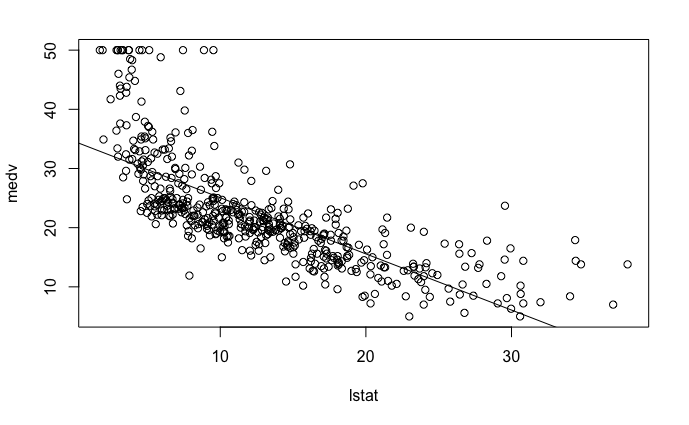

```r
plot(lstat,medv)
abline(lm.fit)
```

```r
plot(lstat,medv,pch="+")
abline(lm.fit,lwd=3)
```

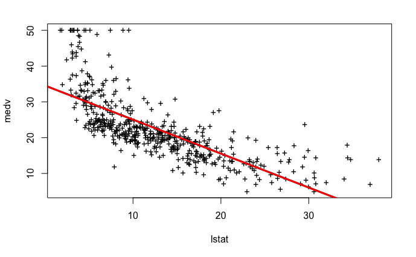

```r
abline(lm.fit,lwd=3,col="red")
```

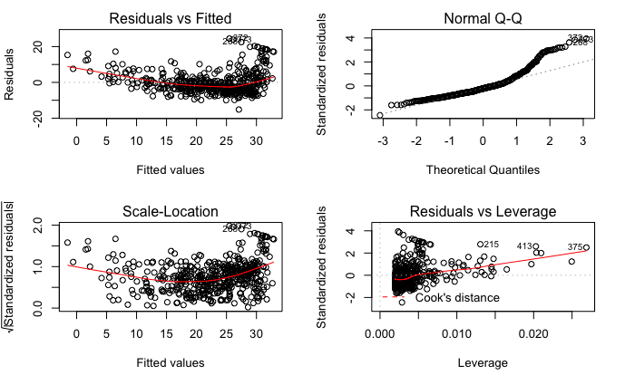

```r
par(mfrow=c(2,2))
plot(lm.fit)
```

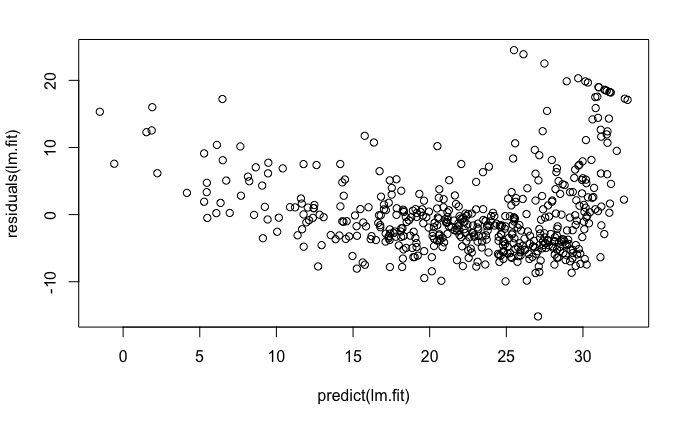

```r
plot(predict(lm.fit), residuals(lm.fit))
```

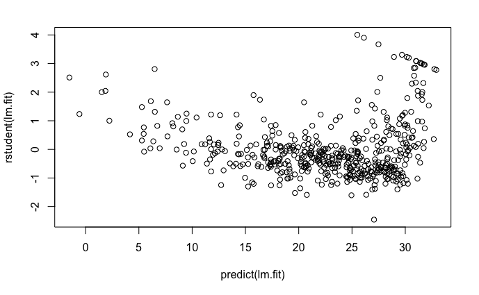

```r
plot(predict(lm.fit),rstudent(lm.fit))
```

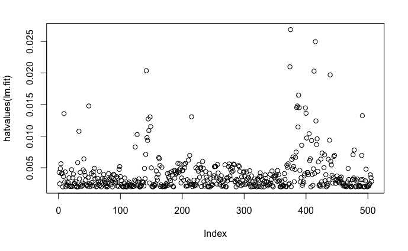

```r
plot(hatvalues(lm.fit))
```

```r
which.max(hatvalues(lm.fit))
```

```
375
375
```

```r
lm.fit=lm(medv~lstat+age,data=Boston)
summary(lm.fit)
```

```
Call:
lm(formula = medv ~ lstat + age, data = Boston)

Residuals:
    Min      1Q  Median      3Q     Max
-15.981  -3.978  -1.283   1.968  23.158

Coefficients:
            Estimate Std. Error t value Pr(>|t|)
(Intercept) 33.22276    0.73085  45.458  < 2e-16 ***
lstat       -1.03207    0.04819 -21.416  < 2e-16 ***
age          0.03454    0.01223   2.826  0.00491 **
---
Signif. codes:  0 ‘***’ 0.001 ‘**’ 0.01 ‘*’ 0.05 ‘.’ 0.1 ‘ ’ 1

Residual standard error: 6.173 on 503 degrees of freedom
Multiple R-squared:  0.5513,    Adjusted R-squared:  0.5495
F-statistic:   309 on 2 and 503 DF,  p-value: < 2.2e-16
```

```r
lm.fit=lm(medv~.,data=Boston)
summary(lm.fit)
```

```
Call:
lm(formula = medv ~ ., data = Boston)

Residuals:
    Min      1Q  Median      3Q     Max
-15.595  -2.730  -0.518   1.777  26.199

Coefficients:
              Estimate Std. Error t value Pr(>|t|)
(Intercept)  3.646e+01  5.103e+00   7.144 3.28e-12 ***
crim        -1.080e-01  3.286e-02  -3.287 0.001087 **
zn           4.642e-02  1.373e-02   3.382 0.000778 ***
indus        2.056e-02  6.150e-02   0.334 0.738288
chas         2.687e+00  8.616e-01   3.118 0.001925 **
nox         -1.777e+01  3.820e+00  -4.651 4.25e-06 ***
rm           3.810e+00  4.179e-01   9.116  < 2e-16 ***
age          6.922e-04  1.321e-02   0.052 0.958229
dis         -1.476e+00  1.995e-01  -7.398 6.01e-13 ***
rad          3.060e-01  6.635e-02   4.613 5.07e-06 ***
tax         -1.233e-02  3.760e-03  -3.280 0.001112 **
ptratio     -9.527e-01  1.308e-01  -7.283 1.31e-12 ***
black        9.312e-03  2.686e-03   3.467 0.000573 ***
lstat       -5.248e-01  5.072e-02 -10.347  < 2e-16 ***
---
Signif. codes:  0 ‘***’ 0.001 ‘**’ 0.01 ‘*’ 0.05 ‘.’ 0.1 ‘ ’ 1

Residual standard error: 4.745 on 492 degrees of freedom
Multiple R-squared:  0.7406,    Adjusted R-squared:  0.7338
F-statistic: 108.1 on 13 and 492 DF,  p-value: < 2.2e-16
```

```r
library(car)
vif(lm.fit)
```

```
    crim       zn    indus     chas      nox       rm      age      dis      rad      tax
1.792192 2.298758 3.991596 1.073995 4.393720 1.933744 3.100826 3.955945 7.484496 9.008554
 ptratio    black    lstat
1.799084 1.348521 2.941491
```

```r
lm.fit1=lm(medv~.-age,data=Boston)
summary(lm.fit1)
```

```
Call:
lm(formula = medv ~ . - age, data = Boston)

Residuals:
     Min       1Q   Median       3Q      Max
-15.6054  -2.7313  -0.5188   1.7601  26.2243

Coefficients:
              Estimate Std. Error t value Pr(>|t|)
(Intercept)  36.436927   5.080119   7.172 2.72e-12 ***
crim         -0.108006   0.032832  -3.290 0.001075 **
zn            0.046334   0.013613   3.404 0.000719 ***
indus         0.020562   0.061433   0.335 0.737989
chas          2.689026   0.859598   3.128 0.001863 **
nox         -17.713540   3.679308  -4.814 1.97e-06 ***
rm            3.814394   0.408480   9.338  < 2e-16 ***
dis          -1.478612   0.190611  -7.757 5.03e-14 ***
rad           0.305786   0.066089   4.627 4.75e-06 ***
tax          -0.012329   0.003755  -3.283 0.001099 **
ptratio      -0.952211   0.130294  -7.308 1.10e-12 ***
black         0.009321   0.002678   3.481 0.000544 ***
lstat        -0.523852   0.047625 -10.999  < 2e-16 ***
---
Signif. codes:  0 ‘***’ 0.001 ‘**’ 0.01 ‘*’ 0.05 ‘.’ 0.1 ‘ ’ 1

Residual standard error: 4.74 on 493 degrees of freedom
Multiple R-squared:  0.7406,    Adjusted R-squared:  0.7343
F-statistic: 117.3 on 12 and 493 DF,  p-value: < 2.2e-16
```

## Interaction Terms

```r
summary(lm(medv~lstat*age,data=Boston))
```

```
Call:
lm(formula = medv ~ lstat * age, data = Boston)

Residuals:
    Min      1Q  Median      3Q     Max
-15.806  -4.045  -1.333   2.085  27.552

Coefficients:
              Estimate Std. Error t value Pr(>|t|)
(Intercept) 36.0885359  1.4698355  24.553  < 2e-16 ***
lstat       -1.3921168  0.1674555  -8.313 8.78e-16 ***
age         -0.0007209  0.0198792  -0.036   0.9711
lstat:age    0.0041560  0.0018518   2.244   0.0252 *
---
Signif. codes:  0 ‘***’ 0.001 ‘**’ 0.01 ‘*’ 0.05 ‘.’ 0.1 ‘ ’ 1

Residual standard error: 6.149 on 502 degrees of freedom
Multiple R-squared:  0.5557,    Adjusted R-squared:  0.5531
F-statistic: 209.3 on 3 and 502 DF,  p-value: < 2.2e-16
```

## Non-linear Transformations of the Predictors

```r
lm.fit2=lm(medv~lstat+I(lstat^2))
summary(lm.fit2)
```

```
Call:
lm(formula = medv ~ lstat + I(lstat^2))

Residuals:
     Min       1Q   Median       3Q      Max
-15.2834  -3.8313  -0.5295   2.3095  25.4148

Coefficients:
             Estimate Std. Error t value Pr(>|t|)
(Intercept) 42.862007   0.872084   49.15   <2e-16 ***
lstat       -2.332821   0.123803  -18.84   <2e-16 ***
I(lstat^2)   0.043547   0.003745   11.63   <2e-16 ***
---
Signif. codes:  0 ‘***’ 0.001 ‘**’ 0.01 ‘*’ 0.05 ‘.’ 0.1 ‘ ’ 1

Residual standard error: 5.524 on 503 degrees of freedom
Multiple R-squared:  0.6407,    Adjusted R-squared:  0.6393
F-statistic: 448.5 on 2 and 503 DF,  p-value: < 2.2e-16
```

```r
lm.fit=lm(medv~lstat)
anova(lm.fit,lm.fit2)
```

```
Analysis of Variance Table

Model 1: medv ~ lstat
Model 2: medv ~ lstat + I(lstat^2)
  Res.Df   RSS Df Sum of Sq     F    Pr(>F)
1    504 19472
2    503 15347  1    4125.1 135.2 < 2.2e-16 ***
---
Signif. codes:  0 ‘***’ 0.001 ‘**’ 0.01 ‘*’ 0.05 ‘.’ 0.1 ‘ ’ 1
```

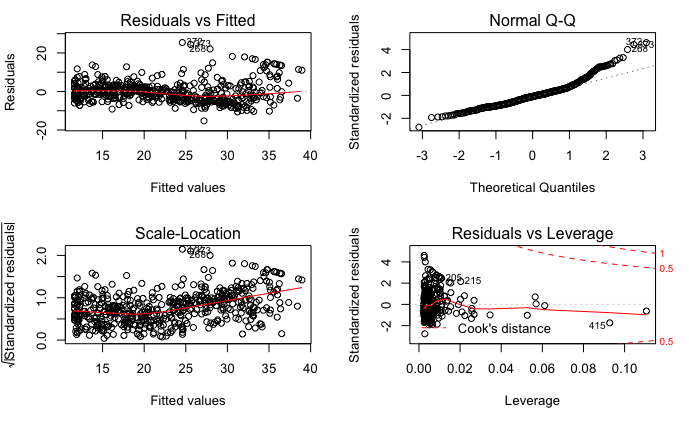

```r
par(mfrow=c(2,2))
plot(lm.fit2)
```

```r
lm.fit5=lm(medv~poly(lstat,5))
summary(lm.fit5)
```

```
Call:
lm(formula = medv ~ poly(lstat, 5))

Residuals:
     Min       1Q   Median       3Q      Max
-13.5433  -3.1039  -0.7052   2.0844  27.1153

Coefficients:
                 Estimate Std. Error t value Pr(>|t|)
(Intercept)       22.5328     0.2318  97.197  < 2e-16 ***
poly(lstat, 5)1 -152.4595     5.2148 -29.236  < 2e-16 ***
poly(lstat, 5)2   64.2272     5.2148  12.316  < 2e-16 ***
poly(lstat, 5)3  -27.0511     5.2148  -5.187 3.10e-07 ***
poly(lstat, 5)4   25.4517     5.2148   4.881 1.42e-06 ***
poly(lstat, 5)5  -19.2524     5.2148  -3.692 0.000247 ***
---
Signif. codes:  0 ‘***’ 0.001 ‘**’ 0.01 ‘*’ 0.05 ‘.’ 0.1 ‘ ’ 1

Residual standard error: 5.215 on 500 degrees of freedom
Multiple R-squared:  0.6817,    Adjusted R-squared:  0.6785
F-statistic: 214.2 on 5 and 500 DF,  p-value: < 2.2e-16
```

```r
summary(lm(medv~log(rm),data=Boston))
```

```
Call:
lm(formula = medv ~ log(rm), data = Boston)

Residuals:
    Min      1Q  Median      3Q     Max
-19.487  -2.875  -0.104   2.837  39.816

Coefficients:
            Estimate Std. Error t value Pr(>|t|)
(Intercept)  -76.488      5.028  -15.21   <2e-16 ***
log(rm)       54.055      2.739   19.73   <2e-16 ***
---
Signif. codes:  0 ‘***’ 0.001 ‘**’ 0.01 ‘*’ 0.05 ‘.’ 0.1 ‘ ’ 1

Residual standard error: 6.915 on 504 degrees of freedom
Multiple R-squared:  0.4358,    Adjusted R-squared:  0.4347
F-statistic: 389.3 on 1 and 504 DF,  p-value: < 2.2e-16
```

## Qualitative Predictors

```r
fix(Carseats)
```

[output not shown]

```r
names(Carseats)
```

```
 [1] "Sales"       "CompPrice"   "Income"      "Advertising" "Population"  "Price"
 [7] "ShelveLoc"   "Age"         "Education"   "Urban"       "US"
```

```r
lm.fit=lm(Sales~.+Income:Advertising+Price:Age,data=Carseats)
summary(lm.fit)
```

```
Call:
lm(formula = Sales ~ . + Income:Advertising + Price:Age, data = Carseats)

Residuals:
    Min      1Q  Median      3Q     Max
-2.9208 -0.7503  0.0177  0.6754  3.3413

Coefficients:
                     Estimate Std. Error t value Pr(>|t|)
(Intercept)         6.5755654  1.0087470   6.519 2.22e-10 ***
CompPrice           0.0929371  0.0041183  22.567  < 2e-16 ***
Income              0.0108940  0.0026044   4.183 3.57e-05 ***
Advertising         0.0702462  0.0226091   3.107 0.002030 **
Population          0.0001592  0.0003679   0.433 0.665330
Price              -0.1008064  0.0074399 -13.549  < 2e-16 ***
ShelveLocGood       4.8486762  0.1528378  31.724  < 2e-16 ***
ShelveLocMedium     1.9532620  0.1257682  15.531  < 2e-16 ***
Age                -0.0579466  0.0159506  -3.633 0.000318 ***
Education          -0.0208525  0.0196131  -1.063 0.288361
UrbanYes            0.1401597  0.1124019   1.247 0.213171
USYes              -0.1575571  0.1489234  -1.058 0.290729
Income:Advertising  0.0007510  0.0002784   2.698 0.007290 **
Price:Age           0.0001068  0.0001333   0.801 0.423812
---
Signif. codes:  0 ‘***’ 0.001 ‘**’ 0.01 ‘*’ 0.05 ‘.’ 0.1 ‘ ’ 1

Residual standard error: 1.011 on 386 degrees of freedom
Multiple R-squared:  0.8761,    Adjusted R-squared:  0.8719
F-statistic:   210 on 13 and 386 DF,  p-value: < 2.2e-16
```

## Writing Functions

```r
LoadLibraries=function(){
  library(ISLR)
  library(MASS)
  print("The libraries have been loaded.")
}
LoadLibraries()
```

```
[1] "The libraries have been loaded."
```

# Exercises

1. Describe the null hypotheses to which the p-values given in Table 3.4 correspond. Explain what conclusions you can draw based on these p-values. Your explanation should be phrased in terms of sales, TV, radio, and newspaper, rather than in terms of the coefficients of the linear model.

In Table 3.4, the null hypothesis for “TV” is that in the presence of radio ads and newspaper ads, TV ads have no effect on sales. Similarly, the null hypothesis for “radio” is that in the presence of TV and newspaper ads, radio ads have no effect on sales. (And there is a similar null hypothesis for “newspaper”.) The low p-values of TV and radio suggest that the null hypotheses are false for TV and radio. The high p-value of newspaper suggests that the null hypothesis is true for newspaper.

2. Carefully explain the differences between the KNN classifier and KNN regression methods.

KNN classifier and KNN regression methods are closely related in formula. However, the final result of KNN classifier is the classification output for Y (qualitative), where as the output for a KNN regression predicts the quantitative value for f(X).

3. Suppose we have a data set with five predictors, X1 = GPA, X2 = IQ, X3 = Gender (1 for Female and 0 for Male), X4 = Interaction between GPA and IQ, and X5 = Interaction between GPA and Gender. The response is starting salary after graduation (in thousands of dollars). Suppose we use least squares to fit the model, and get βˆ0 = 50, βˆ1 = 20, βˆ2 = 0.07, βˆ3 = 35, βˆ4 = 0.01, βˆ5 = −10.
1. Which answer is correct, and why?
1. For a fixed value of IQ and GPA, males earn more on average than females.
2. For a fixed value of IQ and GPA, females earn more on average than males.
3. For a fixed value of IQ and GPA, males earn more on average than females provided that the GPA is high enough.
4. For a fixed value of IQ and GPA, females earn more on average than males provided that the GPA is high enough.
1. Y = 50 + 20 k_1 + 0.07 k_2 + 35 gender + 0.01(k_1 * k_2) - 10 (k_1 * gender) male: (gender = 0) 50 + 20 k_1 + 0.07 k_2 + 0.01(k_1 * k_2) female: (gender = 1) 50 + 20 k_1 + 0.07 k_2 + 35 + 0.01(k_1 * k_2) - 10 (k_1) Once the GPA is high enough, males earn more on average. => iii.
2. Predict the salary of a female with IQ of 110 and a GPA of 4.0.
3. Y(Gender = 1, IQ = 110, GPA = 4.0) = 50 + 20 * 4 + 0.07 * 110 + 35 + 0.01 (4 * 110) - 10 * 4 = 137.1
4. True or false: Since the coefficient for the GPA/IQ interaction term is very small, there is very little evidence of an interaction effect. Justify your answer.
5. False. We must examine the p-value of the regression coefficient to determine if the interaction term is statistically significant or not.
4. I collect a set of data (n = 100 observations) containing a single predictor and a quantitative response. I then fit a linear regression model to the data, as well as a separate cubic regression, i.e. Y = β0 + β1X + β2X2 + β3X3 + .
1. Suppose that the true relationship between X and Y is linear, i.e. Y = β0 + β1X + . Consider the training residual sum of squares (RSS) for the linear regression, and also the training RSS for the cubic regression. Would we expect one to be lower than the other, would we expect them to be the same, or is there not enough information to tell? Justify your answer. 3.7 Exercises 121
2. I would expect the polynomial regression to have a lower training RSS than the linear regression because it could make a tighter fit against data that matched with a wider irreducible error (Var(epsilon)).
3. Answer (a) using test rather than training RSS.

Converse to (a), I would expect the polynomial regression to have a higher test RSS as the overfit from training would have more error than the linear regression.

3. Suppose that the true relationship between X and Y is not linear, but we don’t know how far it is from linear. Consider the training RSS for the linear regression, and also the training RSS for the cubic regression. Would we expect one to be lower than the other, would we expect them to be the same, or is there not enough information to tell? Justify your answer.

Polynomial regression has lower train RSS than the linear fit because of higher flexibility: no matter what the underlying true relationshop is the more flexible model will closer follow points and reduce train RSS. An example of this beahvior is shown on Figure~2.9 from Chapter 2.

4. Answer (c) using test rather than training RSS.

There is not enough information to tell which test RSS would be lower for either regression given the problem statement is defined as not knowing “how far it is from linear”. If it is closer to linear than cubic, the linear regression test RSS could be lower than the cubic regression test RSS. Or, if it is closer to cubic than linear, the cubic regression test RSS could be lower than the linear regression test RSS. It is dues to bias-variance tradeoff: it is not clear what level of flexibility will fit data better.

6. Using (3.4), argue that in the case of simple linear regression, the least squares line always passes through the point (¯x, y¯).

y = B_0 + B_1 x from (3.4): B_0 = avg(y) - B_1 avg(x) right hand side will equal 0 if (avg(x), avg(y)) is a point on the line 0 = B_0 + B_1 avg(x) - avg(y) 0 = (avg(y) - B_1 avg(x)) + B_1 avg(x) - avg(y) 0 = 0

## Applied

```r
lm.fit = lm(mpg~horsepower, data=Auto)
summary(lm.fit)
```

```
Call:
lm(formula = mpg ~ horsepower, data = Auto)

Residuals:
     Min       1Q   Median       3Q      Max
-13.5710  -3.2592  -0.3435   2.7630  16.9240

Coefficients:
             Estimate Std. Error t value Pr(>|t|)
(Intercept) 39.935861   0.717499   55.66   <2e-16 ***
horsepower  -0.157845   0.006446  -24.49   <2e-16 ***
---
Signif. codes:  0 ‘***’ 0.001 ‘**’ 0.01 ‘*’ 0.05 ‘.’ 0.1 ‘ ’ 1

Residual standard error: 4.906 on 390 degrees of freedom
  (5 observations deleted due to missingness)
Multiple R-squared:  0.6059,    Adjusted R-squared:  0.6049
F-statistic: 599.7 on 1 and 390 DF,  p-value: < 2.2e-16
```

# i. Yes, there is a relationship between predictor and response

# ii. p-value is close to 0: relationship is strong

# iii. Coefficient is negative: relationship is negative

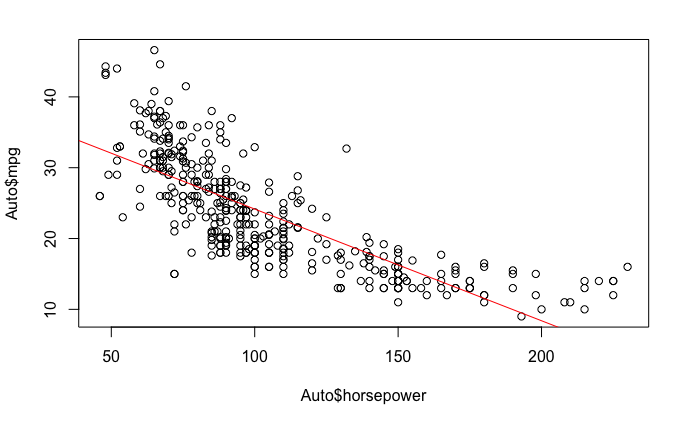

```r
plot(Auto$horsepower, Auto$mpg)
abline(lm.fit, col='red')
```

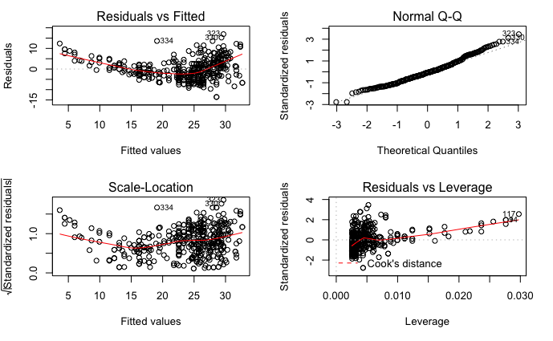

```r
par(mfrow=c(2,2))
plot(lm.fit)
```

# 9.

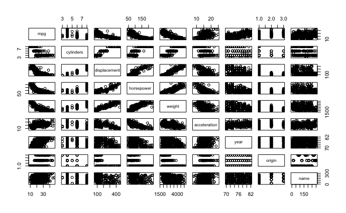

```r
pairs(Auto)
```

```r
cor(subset(Auto,select=-name))
```

```
                    mpg  cylinders displacement horsepower     weight acceleration
mpg           1.0000000 -0.7762599   -0.8044430         NA -0.8317389    0.4222974
cylinders    -0.7762599  1.0000000    0.9509199         NA  0.8970169   -0.5040606
displacement -0.8044430  0.9509199    1.0000000         NA  0.9331044   -0.5441618
horsepower           NA         NA           NA          1         NA           NA
weight       -0.8317389  0.8970169    0.9331044         NA  1.0000000   -0.4195023
acceleration  0.4222974 -0.5040606   -0.5441618         NA -0.4195023    1.0000000
year          0.5814695 -0.3467172   -0.3698041         NA -0.3079004    0.2829009
origin        0.5636979 -0.5649716   -0.6106643         NA -0.5812652    0.2100836
                   year     origin
mpg           0.5814695  0.5636979
cylinders    -0.3467172 -0.5649716
displacement -0.3698041 -0.6106643
horsepower           NA         NA
weight       -0.3079004 -0.5812652
acceleration  0.2829009  0.2100836
year          1.0000000  0.1843141
origin        0.1843141  1.0000000
```

```r
lm.fit = lm(mpg~.-name,data=Auto)
summary(lm.fit)
```

```
Call:
lm(formula = mpg ~ . - name, data = Auto)

Residuals:
    Min      1Q  Median      3Q     Max
-9.5903 -2.1565 -0.1169  1.8690 13.0604

Coefficients:
               Estimate Std. Error t value Pr(>|t|)
(Intercept)  -17.218435   4.644294  -3.707  0.00024 ***
cylinders     -0.493376   0.323282  -1.526  0.12780
displacement   0.019896   0.007515   2.647  0.00844 **
horsepower    -0.016951   0.013787  -1.230  0.21963
weight        -0.006474   0.000652  -9.929  < 2e-16 ***
acceleration   0.080576   0.098845   0.815  0.41548
year           0.750773   0.050973  14.729  < 2e-16 ***
origin         1.426141   0.278136   5.127 4.67e-07 ***
---
Signif. codes:  0 ‘***’ 0.001 ‘**’ 0.01 ‘*’ 0.05 ‘.’ 0.1 ‘ ’ 1

Residual standard error: 3.328 on 384 degrees of freedom
  (5 observations deleted due to missingness)
Multiple R-squared:  0.8215,    Adjusted R-squared:  0.8182
F-statistic: 252.4 on 7 and 384 DF,  p-value: < 2.2e-16
```

There is a relationship between predictors and response * `weight`, `year`, `origin` and `displacement` have statistically significant relationships * 0.75 coefficient for `year` suggests that later model year cars have better (higher) `mpg`

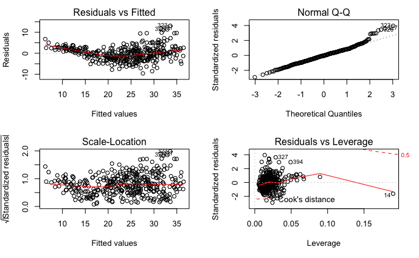

```r
par(mfrow=c(2,2))
plot(lm.fit)
```

Evidence of non-linearity

```r
lm.fit0 <- lm(mpg~displacement+weight+year+origin, data=Auto)
lm.fit1 <- lm(mpg~displacement+weight+year*origin, data=Auto)
lm.fit2 <- lm(mpg~displacement+origin+year*weight, data=Auto)
lm.fit3 <- lm(mpg~year+origin+displacement*weight, data=Auto)
summary(lm.fit0)
```

```
Call:
lm(formula = mpg ~ displacement + weight + year + origin, data = Auto)

Residuals:
    Min      1Q  Median      3Q     Max
-9.8313 -2.1194 -0.0079  1.8070 13.1429

Coefficients:
               Estimate Std. Error t value Pr(>|t|)
(Intercept)  -1.884e+01  3.992e+00  -4.720 3.29e-06 ***
displacement  6.091e-03  4.757e-03   1.280    0.201
weight       -6.657e-03  5.556e-04 -11.980  < 2e-16 ***
year          7.765e-01  4.945e-02  15.700  < 2e-16 ***
origin        1.235e+00  2.653e-01   4.653 4.49e-06 ***
---
Signif. codes:  0 ‘***’ 0.001 ‘**’ 0.01 ‘*’ 0.05 ‘.’ 0.1 ‘ ’ 1

Residual standard error: 3.348 on 392 degrees of freedom
Multiple R-squared:  0.8188,    Adjusted R-squared:  0.8169
F-statistic: 442.7 on 4 and 392 DF,  p-value: < 2.2e-16
```

```r
summary(lm.fit1)
```

```
Call:
lm(formula = mpg ~ displacement + weight + year * origin, data = Auto)

Residuals:
    Min      1Q  Median      3Q     Max
-8.7506 -1.8980 -0.1495  1.7274 12.3853

Coefficients:
               Estimate Std. Error t value Pr(>|t|)
(Intercept)   7.992e+00  8.784e+00   0.910 0.363499
displacement  1.995e-03  4.844e-03   0.412 0.680700
weight       -6.463e-03  5.511e-04 -11.726  < 2e-16 ***
year          4.319e-01  1.120e-01   3.857 0.000134 ***
origin       -1.474e+01  4.682e+00  -3.148 0.001768 **
year:origin   2.056e-01  6.017e-02   3.417 0.000699 ***
---
Signif. codes:  0 ‘***’ 0.001 ‘**’ 0.01 ‘*’ 0.05 ‘.’ 0.1 ‘ ’ 1

Residual standard error: 3.304 on 391 degrees of freedom
Multiple R-squared:  0.824, Adjusted R-squared:  0.8218
F-statistic: 366.2 on 5 and 391 DF,  p-value: < 2.2e-16
```

```r
summary(lm.fit2)
```

```
Call:
lm(formula = mpg ~ displacement + origin + year * weight, data = Auto)

Residuals:
    Min      1Q  Median      3Q     Max
-8.9468 -1.8978 -0.0939  1.6299 12.1542

Coefficients:
               Estimate Std. Error t value Pr(>|t|)
(Intercept)  -1.092e+02  1.277e+01  -8.550 2.81e-16 ***
displacement -1.475e-04  4.540e-03  -0.032 0.974094
origin        9.057e-01  2.528e-01   3.583 0.000382 ***
year          1.986e+00  1.699e-01  11.689  < 2e-16 ***
weight        2.659e-02  4.523e-03   5.879 8.86e-09 ***
year:weight  -4.385e-04  5.926e-05  -7.400 8.41e-13 ***
---
Signif. codes:  0 ‘***’ 0.001 ‘**’ 0.01 ‘*’ 0.05 ‘.’ 0.1 ‘ ’ 1

Residual standard error: 3.14 on 391 degrees of freedom
Multiple R-squared:  0.841, Adjusted R-squared:  0.839
F-statistic: 413.7 on 5 and 391 DF,  p-value: < 2.2e-16
```

```r
summary(lm.fit3)
```

```
Call:
lm(formula = mpg ~ year + origin + displacement * weight, data = Auto)

Residuals:
     Min       1Q   Median       3Q      Max
-10.6296  -1.7668  -0.0223   1.5722  12.4998

Coefficients:
                      Estimate Std. Error t value Pr(>|t|)
(Intercept)         -8.191e+00  3.754e+00  -2.182   0.0297 *
year                 8.249e-01  4.475e-02  18.434  < 2e-16 ***
origin               3.619e-01  2.550e-01   1.419   0.1567
displacement        -7.189e-02  9.115e-03  -7.887 3.13e-14 ***
weight              -1.065e-02  6.475e-04 -16.443  < 2e-16 ***
displacement:weight  2.128e-05  2.197e-06   9.688  < 2e-16 ***
---
Signif. codes:  0 ‘***’ 0.001 ‘**’ 0.01 ‘*’ 0.05 ‘.’ 0.1 ‘ ’ 1

Residual standard error: 3.011 on 391 degrees of freedom
Multiple R-squared:  0.8538,    Adjusted R-squared:  0.852
F-statistic: 456.9 on 5 and 391 DF,  p-value: < 2.2e-16
```

```r
lm.fit4 <- lm(mpg~poly(displacement,3)+weight+year+origin, data=Auto)
lm.fit5 <- lm(mpg~displacement+I(log(weight))+year+origin, data=Auto)
lm.fit6 <- lm(mpg~displacement+I(weight^2)+year+origin, data=Auto)
summary(lm.fit4)
```

```
Call:
lm(formula = mpg ~ poly(displacement, 3) + weight + year + origin,
    data = Auto)

Residuals:
     Min       1Q   Median       3Q      Max
-11.8676  -1.8201   0.0925   1.5715  12.2497

Coefficients:
                         Estimate Std. Error t value Pr(>|t|)
(Intercept)            -2.358e+01  3.761e+00  -6.270 9.57e-10 ***
poly(displacement, 3)1 -1.635e+01  9.814e+00  -1.666  0.09661 .
poly(displacement, 3)2  2.877e+01  3.601e+00   7.989 1.55e-14 ***
poly(displacement, 3)3 -8.410e+00  3.160e+00  -2.661  0.00811 **
weight                 -5.346e-03  5.396e-04  -9.909  < 2e-16 ***
year                    8.236e-01  4.617e-02  17.840  < 2e-16 ***
origin                  2.450e-01  2.736e-01   0.895  0.37120
---
Signif. codes:  0 ‘***’ 0.001 ‘**’ 0.01 ‘*’ 0.05 ‘.’ 0.1 ‘ ’ 1

Residual standard error: 3.099 on 390 degrees of freedom
Multiple R-squared:  0.8456,    Adjusted R-squared:  0.8432
F-statistic: 355.9 on 6 and 390 DF,  p-value: < 2.2e-16
```

```r
summary(lm.fit5)
```

```
Call:
lm(formula = mpg ~ displacement + I(log(weight)) + year + origin,
    data = Auto)

Residuals:
    Min      1Q  Median      3Q     Max
-9.7232 -1.8862  0.0032  1.5833 12.9262

Coefficients:
                 Estimate Std. Error t value Pr(>|t|)
(Intercept)    132.626241  10.979843  12.079  < 2e-16 ***
displacement     0.008248   0.004029   2.047 0.041287 *
I(log(weight)) -21.822624   1.440808 -15.146  < 2e-16 ***
year             0.810625   0.046100  17.584  < 2e-16 ***
origin           0.842756   0.248393   3.393 0.000762 ***
---
Signif. codes:  0 ‘***’ 0.001 ‘**’ 0.01 ‘*’ 0.05 ‘.’ 0.1 ‘ ’ 1

Residual standard error: 3.109 on 392 degrees of freedom
Multiple R-squared:  0.8438,    Adjusted R-squared:  0.8422
F-statistic: 529.5 on 4 and 392 DF,  p-value: < 2.2e-16
```

```r
summary(lm.fit6)
```

```
Call:
lm(formula = mpg ~ displacement + I(weight^2) + year + origin,
    data = Auto)

Residuals:
     Min       1Q   Median       3Q      Max
-10.1372  -2.2931  -0.1553   1.8984  13.4027

Coefficients:
               Estimate Std. Error t value Pr(>|t|)
(Intercept)  -2.633e+01  4.321e+00  -6.093 2.65e-09 ***
displacement -8.942e-03  5.117e-03  -1.747   0.0814 .
I(weight^2)  -7.140e-07  9.084e-08  -7.860 3.74e-14 ***
year          7.373e-01  5.350e-02  13.780  < 2e-16 ***
origin        1.497e+00  2.888e-01   5.185 3.46e-07 ***
---
Signif. codes:  0 ‘***’ 0.001 ‘**’ 0.01 ‘*’ 0.05 ‘.’ 0.1 ‘ ’ 1

Residual standard error: 3.638 on 392 degrees of freedom
Multiple R-squared:  0.7861,    Adjusted R-squared:  0.7839
F-statistic: 360.2 on 4 and 392 DF,  p-value: < 2.2e-16
```

```r
data(Carseats)
lm.fit <- lm(Sales ~ Price + Urban + US, data=Carseats)
summary(lm.fit)
```

```
Call:
lm(formula = Sales ~ Price + Urban + US, data = Carseats)

Residuals:
    Min      1Q  Median      3Q     Max
-6.9206 -1.6220 -0.0564  1.5786  7.0581

Coefficients:
             Estimate Std. Error t value Pr(>|t|)
(Intercept) 13.043469   0.651012  20.036  < 2e-16 ***
Price       -0.054459   0.005242 -10.389  < 2e-16 ***
UrbanYes    -0.021916   0.271650  -0.081    0.936
USYes        1.200573   0.259042   4.635 4.86e-06 ***
---
Signif. codes:  0 ‘***’ 0.001 ‘**’ 0.01 ‘*’ 0.05 ‘.’ 0.1 ‘ ’ 1

Residual standard error: 2.472 on 396 degrees of freedom
Multiple R-squared:  0.2393,    Adjusted R-squared:  0.2335
F-statistic: 41.52 on 3 and 396 DF,  p-value: < 2.2e-16
```

Sales: sales in thousands at each location Price: price charged for car seats at each location Urban: No/Yes by location US: No/Yes by location

Coefficients for

- Price (-0.054459): Sales drop by 54 for each dollar increase in Price - statistically significant
- UrbanYes (-0.021916): Sales are 22 lower for Urban locations - not statistically significant
- USYes (1.200573): Sales are 1,201 higher in the US locations - statistically significant

Sales = 13.043 - 0.054 x Price - 0.022 x UrbanYes + 1.201 x USYes

Can reject null hypothesis for Price and USYes (coefficients have low p-values)

```r
lm.fit1 = lm(Sales ~ Price + US, data=Carseats)
summary(lm.fit1)
```

```
Call:
lm(formula = Sales ~ Price + US, data = Carseats)

Residuals:
    Min      1Q  Median      3Q     Max
-6.9269 -1.6286 -0.0574  1.5766  7.0515

Coefficients:
            Estimate Std. Error t value Pr(>|t|)
(Intercept) 13.03079    0.63098  20.652  < 2e-16 ***
Price       -0.05448    0.00523 -10.416  < 2e-16 ***
USYes        1.19964    0.25846   4.641 4.71e-06 ***
---
Signif. codes:  0 ‘***’ 0.001 ‘**’ 0.01 ‘*’ 0.05 ‘.’ 0.1 ‘ ’ 1

Residual standard error: 2.469 on 397 degrees of freedom
Multiple R-squared:  0.2393,    Adjusted R-squared:  0.2354
F-statistic: 62.43 on 2 and 397 DF,  p-value: < 2.2e-16
```

```r
confint(lm.fit1)
```

```
                  2.5 %      97.5 %
(Intercept) 11.79032020 14.27126531
Price       -0.06475984 -0.04419543
USYes        0.69151957  1.70776632
```

```r
set.seed(1)
x <- rnorm(100)
y <- 2*x + rnorm(100)
fit.lmY <- lm(y ~ x + 0)
summary(fit.lmY)
```

```
Call:
lm(formula = y ~ x + 0)

Residuals:
    Min      1Q  Median      3Q     Max
-1.9154 -0.6472 -0.1771  0.5056  2.3109

Coefficients:
  Estimate Std. Error t value Pr(>|t|)
x   1.9939     0.1065   18.73   <2e-16 ***
---
Signif. codes:  0 ‘***’ 0.001 ‘**’ 0.01 ‘*’ 0.05 ‘.’ 0.1 ‘ ’ 1

Residual standard error: 0.9586 on 99 degrees of freedom
Multiple R-squared:  0.7798,    Adjusted R-squared:  0.7776
F-statistic: 350.7 on 1 and 99 DF,  p-value: < 2.2e-16
```

Small std. error for coefficient relative to coefficient estimate. p-value is close to zero so statistically significant.

```r
fit.lmX <- lm(x ~ y + 0)
summary(fit.lmX)
```

```
Call:
lm(formula = x ~ y + 0)

Residuals:
    Min      1Q  Median      3Q     Max
-0.8699 -0.2368  0.1030  0.2858  0.8938

Coefficients:
  Estimate Std. Error t value Pr(>|t|)
y  0.39111    0.02089   18.73   <2e-16 ***
---
Signif. codes:  0 ‘***’ 0.001 ‘**’ 0.01 ‘*’ 0.05 ‘.’ 0.1 ‘ ’ 1

Residual standard error: 0.4246 on 99 degrees of freedom
Multiple R-squared:  0.7798,    Adjusted R-squared:  0.7776
F-statistic: 350.7 on 1 and 99 DF,  p-value: < 2.2e-16
```

Same as Part a). Small std. error for coefficient relative to coefficient estimate. p-value is close to zero so statistically significant.

```r
fit.lmY2 <- lm(y ~ x)
fit.lmX2 <- lm(x ~ y)
summary(fit.lmY2)
```

```
Call:
lm(formula = y ~ x)

Residuals:
    Min      1Q  Median      3Q     Max
-1.8768 -0.6138 -0.1395  0.5394  2.3462

Coefficients:
            Estimate Std. Error t value Pr(>|t|)
(Intercept) -0.03769    0.09699  -0.389    0.698
x            1.99894    0.10773  18.556   <2e-16 ***
---
Signif. codes:  0 ‘***’ 0.001 ‘**’ 0.01 ‘*’ 0.05 ‘.’ 0.1 ‘ ’ 1

Residual standard error: 0.9628 on 98 degrees of freedom
Multiple R-squared:  0.7784,    Adjusted R-squared:  0.7762
F-statistic: 344.3 on 1 and 98 DF,  p-value: < 2.2e-16
```

```r
summary(fit.lmX2)
```

```
Call:
lm(formula = x ~ y)

Residuals:
     Min       1Q   Median       3Q      Max
-0.90848 -0.28101  0.06274  0.24570  0.85736

Coefficients:
            Estimate Std. Error t value Pr(>|t|)
(Intercept)  0.03880    0.04266    0.91    0.365
y            0.38942    0.02099   18.56   <2e-16 ***
---
Signif. codes:  0 ‘***’ 0.001 ‘**’ 0.01 ‘*’ 0.05 ‘.’ 0.1 ‘ ’ 1

Residual standard error: 0.4249 on 98 degrees of freedom
Multiple R-squared:  0.7784,    Adjusted R-squared:  0.7762
F-statistic: 344.3 on 1 and 98 DF,  p-value: < 2.2e-16
```

t-statistics for both regressions are 18.56

12 When $x_{i}=y_{i}$, or more generally when the beta denominators are equal $\sum x_{i}^2=\sum y_{i}^2$

```r
# exercise 11 example works
set.seed(1)
x <- rnorm(100)
y <- 2*x + rnorm(100)
fit.lmY <- lm(y ~ x)
fit.lmX <- lm(x ~ y)
summary(fit.lmY)
```

```
Call:
lm(formula = y ~ x)

Residuals:
    Min      1Q  Median      3Q     Max
-1.8768 -0.6138 -0.1395  0.5394  2.3462

Coefficients:
            Estimate Std. Error t value Pr(>|t|)
(Intercept) -0.03769    0.09699  -0.389    0.698
x            1.99894    0.10773  18.556   <2e-16 ***
---
Signif. codes:  0 ‘***’ 0.001 ‘**’ 0.01 ‘*’ 0.05 ‘.’ 0.1 ‘ ’ 1

Residual standard error: 0.9628 on 98 degrees of freedom
Multiple R-squared:  0.7784,    Adjusted R-squared:  0.7762
F-statistic: 344.3 on 1 and 98 DF,  p-value: < 2.2e-16
```

```r
summary(fit.lmX)
```

```
Call:
lm(formula = x ~ y)

Residuals:
     Min       1Q   Median       3Q      Max
-0.90848 -0.28101  0.06274  0.24570  0.85736

Coefficients:
            Estimate Std. Error t value Pr(>|t|)
(Intercept)  0.03880    0.04266    0.91    0.365
y            0.38942    0.02099   18.56   <2e-16 ***
---
Signif. codes:  0 ‘***’ 0.001 ‘**’ 0.01 ‘*’ 0.05 ‘.’ 0.1 ‘ ’ 1

Residual standard error: 0.4249 on 98 degrees of freedom
Multiple R-squared:  0.7784,    Adjusted R-squared:  0.7762
F-statistic: 344.3 on 1 and 98 DF,  p-value: < 2.2e-16
```

```r
set.seed(1)
x <- rnorm(100, mean=1000, sd=0.1)
y <- rnorm(100, mean=1000, sd=0.1)
fit.lmY <- lm(y ~ x)
fit.lmX <- lm(x ~ y)
summary(fit.lmY)
```

```
Call:
lm(formula = y ~ x)

Residuals:
     Min       1Q   Median       3Q      Max
-0.18768 -0.06138 -0.01395  0.05394  0.23462

Coefficients:
              Estimate Std. Error t value Pr(>|t|)
(Intercept) 1001.05662  107.72820   9.292 4.16e-15 ***
x             -0.00106    0.10773  -0.010    0.992
---
Signif. codes:  0 ‘***’ 0.001 ‘**’ 0.01 ‘*’ 0.05 ‘.’ 0.1 ‘ ’ 1

Residual standard error: 0.09628 on 98 degrees of freedom
Multiple R-squared:  9.887e-07, Adjusted R-squared:  -0.0102
F-statistic: 9.689e-05 on 1 and 98 DF,  p-value: 0.9922
```

```r
summary(fit.lmX)
```

```
Call:
lm(formula = x ~ y)

Residuals:
      Min        1Q    Median        3Q       Max
-0.232416 -0.060361  0.000536  0.058305  0.229316

Coefficients:
              Estimate Std. Error t value Pr(>|t|)
(Intercept)  1.001e+03  9.472e+01   10.57   <2e-16 ***
y           -9.324e-04  9.472e-02   -0.01    0.992
---
Signif. codes:  0 ‘***’ 0.001 ‘**’ 0.01 ‘*’ 0.05 ‘.’ 0.1 ‘ ’ 1

Residual standard error: 0.09028 on 98 degrees of freedom
Multiple R-squared:  9.887e-07, Adjusted R-squared:  -0.0102
F-statistic: 9.689e-05 on 1 and 98 DF,  p-value: 0.9922
```

13

```r
set.seed(1)
x <- rnorm(100)  # mean=0, sd=1 is default
```

```r
eps <- rnorm(100, sd=0.25^0.5)
```

```r
y <- -1 + 0.5*x + eps  # eps=epsilon=e
length(y)
```

```
[1] 100
```

- length is 100
- $\beta_{0}=-1$
- $\beta_{1}=0.5$

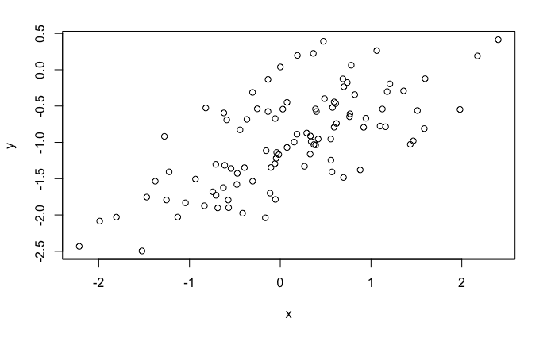

```r
plot(x,y)
```

x and y seem to be positively correlated

```r
fit.lm <- lm(y ~ x)
summary(fit.lm)
```

```
Call:
lm(formula = y ~ x)

Residuals:
     Min       1Q   Median       3Q      Max
-0.93842 -0.30688 -0.06975  0.26970  1.17309

Coefficients:
            Estimate Std. Error t value Pr(>|t|)
(Intercept) -1.01885    0.04849 -21.010  < 2e-16 ***
x            0.49947    0.05386   9.273 4.58e-15 ***
---
Signif. codes:  0 ‘***’ 0.001 ‘**’ 0.01 ‘*’ 0.05 ‘.’ 0.1 ‘ ’ 1

Residual standard error: 0.4814 on 98 degrees of freedom
Multiple R-squared:  0.4674,    Adjusted R-squared:  0.4619
F-statistic: 85.99 on 1 and 98 DF,  p-value: 4.583e-15
```

Estimated $\hat{\beta_{0}}=-1.019$ and $\hat{\beta_{1}}=0.499$, which are close to actual betas used to generate `y`

```r
plot(x,y)
abline(-1, 0.5, col="blue")  # true regression
```

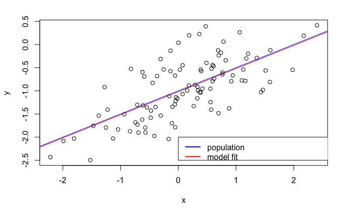

```r
abline(fit.lm, col="red")    # fitted regression
legend(x = c(0,2.7),
       y = c(-2.5,-2),
       legend = c("population", "model fit"),
       col = c("blue","red"), lwd=2 )
```

```r
fit.lm1 <- lm(y~x+I(x^2))
summary(fit.lm1)
```

```
Call:
lm(formula = y ~ x + I(x^2))

Residuals:
     Min       1Q   Median       3Q      Max
-0.98252 -0.31270 -0.06441  0.29014  1.13500

Coefficients:
            Estimate Std. Error t value Pr(>|t|)
(Intercept) -0.97164    0.05883 -16.517  < 2e-16 ***
x            0.50858    0.05399   9.420  2.4e-15 ***
I(x^2)      -0.05946    0.04238  -1.403    0.164
---
Signif. codes:  0 ‘***’ 0.001 ‘**’ 0.01 ‘*’ 0.05 ‘.’ 0.1 ‘ ’ 1

Residual standard error: 0.479 on 97 degrees of freedom
Multiple R-squared:  0.4779,    Adjusted R-squared:  0.4672
F-statistic:  44.4 on 2 and 97 DF,  p-value: 2.038e-14
```

```r
anova(fit.lm, fit.lm1)
```

```
Analysis of Variance Table

Model 1: y ~ x
Model 2: y ~ x + I(x^2)
  Res.Df    RSS Df Sum of Sq      F Pr(>F)
1     98 22.709
2     97 22.257  1   0.45163 1.9682 0.1638
```

No evidence of better fit based on high p-value of coefficient for X^2. Estimated coefficient for $\hat{\beta_{1}}$ is farther from true value. Anova test also suggests polynomial fit is not any better.

```r
eps2 <- rnorm(100, sd=0.1)  # prior sd was 0.5
y2 <- -1 + 0.5*x + eps2
fit.lm2 <- lm(y2 ~ x)
summary(fit.lm2)
```

```
Call:
lm(formula = y2 ~ x)

Residuals:
      Min        1Q    Median        3Q       Max
-0.291411 -0.048230 -0.004533  0.064924  0.264157

Coefficients:
            Estimate Std. Error t value Pr(>|t|)
(Intercept) -0.99726    0.01047  -95.25   <2e-16 ***
x            0.50212    0.01163   43.17   <2e-16 ***
---
Signif. codes:  0 ‘***’ 0.001 ‘**’ 0.01 ‘*’ 0.05 ‘.’ 0.1 ‘ ’ 1

Residual standard error: 0.1039 on 98 degrees of freedom
Multiple R-squared:  0.9501,    Adjusted R-squared:  0.9495
F-statistic:  1864 on 1 and 98 DF,  p-value: < 2.2e-16
```

```r
plot(x, y2)
abline(-1, 0.5, col="blue")   # true regression
```

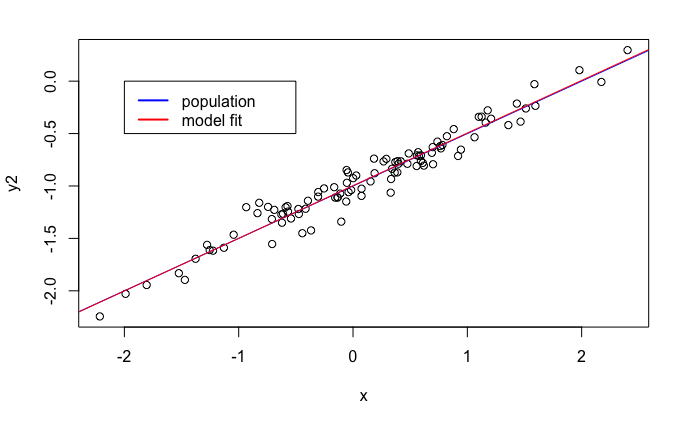

```r
abline(fit.lm2, col="red")    # fitted regression
legend(x = c(-2,-0.5),
       y = c(-0.5,0),
       legend = c("population", "model fit"),
       col = c("blue","red"), lwd=2 )
```

Decreased variance along regression line. Fit for original y was already very good, so coef estimates are about the same for reduced epsilon. However, RSE and R^2 values are much improved.

```r
eps3 <- rnorm(100, sd=1)  # orig sd was 0.5
y3 <- -1 + 0.5*x + eps3
fit.lm3 <- lm(y3 ~ x)
summary(fit.lm3)
```

```
Call:
lm(formula = y3 ~ x)

Residuals:
     Min       1Q   Median       3Q      Max
-2.51626 -0.54525 -0.03776  0.67289  1.87887

Coefficients:
            Estimate Std. Error t value Pr(>|t|)
(Intercept)  -0.9423     0.1003  -9.397 2.47e-15 ***
x             0.4443     0.1114   3.989 0.000128 ***
---
Signif. codes:  0 ‘***’ 0.001 ‘**’ 0.01 ‘*’ 0.05 ‘.’ 0.1 ‘ ’ 1

Residual standard error: 0.9955 on 98 degrees of freedom
Multiple R-squared:  0.1397,    Adjusted R-squared:  0.1309
F-statistic: 15.91 on 1 and 98 DF,  p-value: 0.000128
```

```r
plot(x, y3)
abline(-1, 0.5, col="blue")   # true regression
```

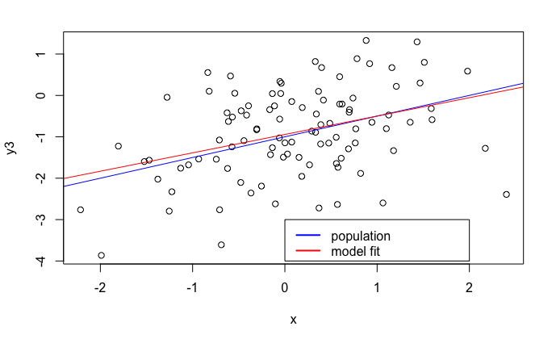

```r
abline(fit.lm3, col="red")    # fitted regression
legend(x = c(0,2),
       y = c(-4,-3),
       legend = c("population", "model fit"),
       col = c("blue","red"), lwd=2 )
```

Coefficient estimates are farther from true value (but not by too much). And, the RSE and R^2 values are worse.

```r
confint(fit.lm)
```

```
                 2.5 %     97.5 %
(Intercept) -1.1150804 -0.9226122
x            0.3925794  0.6063602
```

```r
confint(fit.lm2)
```

```
                 2.5 %     97.5 %
(Intercept) -1.0180413 -0.9764850
x            0.4790377  0.5251957
```

```r
confint(fit.lm3)
```

```
                 2.5 %     97.5 %
(Intercept) -1.1413399 -0.7433293
x            0.2232721  0.6653558
```

Confidence intervals are tighter for original populations with smaller variance

14

```r
set.seed(1)
x1 <- runif(100)
x2 <- 0.5*x1 + rnorm(100)/10
y <- 2 + 2*x1 + 0.3*x2 + rnorm(100)
```

Population regression is $y = \beta_{0} + \beta_{1} x_1 + \beta_{2} x_2 + \varepsilon$, where $\beta_{0}=2$, $\beta_{1}=2$ and $\beta_{2}=0.3$

```r
cor(x1,x2)
```

```
[1] 0.8351212
```

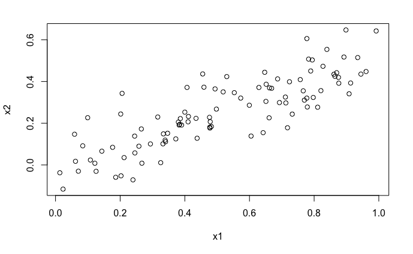

```r
plot(x1,x2)
```

```r
fit.lm <- lm(y~x1+x2)
summary(fit.lm)
```

```
Call:
lm(formula = y ~ x1 + x2)

Residuals:
    Min      1Q  Median      3Q     Max
-2.8311 -0.7273 -0.0537  0.6338  2.3359

Coefficients:
            Estimate Std. Error t value Pr(>|t|)
(Intercept)   2.1305     0.2319   9.188 7.61e-15 ***
x1            1.4396     0.7212   1.996   0.0487 *
x2            1.0097     1.1337   0.891   0.3754
---
Signif. codes:  0 ‘***’ 0.001 ‘**’ 0.01 ‘*’ 0.05 ‘.’ 0.1 ‘ ’ 1

Residual standard error: 1.056 on 97 degrees of freedom
Multiple R-squared:  0.2088,    Adjusted R-squared:  0.1925
F-statistic:  12.8 on 2 and 97 DF,  p-value: 1.164e-05
```

Estimated beta coefficients are $\hat{\beta_{0}}=2.13$, $\hat{\beta_{1}}=1.44$ and $\hat{\beta_{2}}=1.01$. Coefficient for x1 is statistically significant but the coefficient for x2 is not given the presense of x1. These betas try to estimate the population betas: $\hat{\beta_{0}}$ is close (rounds to 2), $\hat{\beta_{1}}$ is 1.44 instead of 2 with a high standard error and $\hat{\beta_{2}}$ is farthest off.

Reject $H_0 : \beta_1=0$; Cannot reject $H_0 : \beta_2=0$

```r
fit.lm1 <- lm(y~x1)
summary(fit.lm1)
```

```
Call:
lm(formula = y ~ x1)

Residuals:
     Min       1Q   Median       3Q      Max
-2.89495 -0.66874 -0.07785  0.59221  2.45560

Coefficients:
            Estimate Std. Error t value Pr(>|t|)
(Intercept)   2.1124     0.2307   9.155 8.27e-15 ***
x1            1.9759     0.3963   4.986 2.66e-06 ***
---
Signif. codes:  0 ‘***’ 0.001 ‘**’ 0.01 ‘*’ 0.05 ‘.’ 0.1 ‘ ’ 1

Residual standard error: 1.055 on 98 degrees of freedom
Multiple R-squared:  0.2024,    Adjusted R-squared:  0.1942
F-statistic: 24.86 on 1 and 98 DF,  p-value: 2.661e-06
```

p-value is close to 0, can reject $H_0 : \beta_1=0$

```r
fit.lm2 <- lm(y~x2)
summary(fit.lm2)
```

```
Call:
lm(formula = y ~ x2)

Residuals:
     Min       1Q   Median       3Q      Max
-2.62687 -0.75156 -0.03598  0.72383  2.44890

Coefficients:
            Estimate Std. Error t value Pr(>|t|)
(Intercept)   2.3899     0.1949   12.26  < 2e-16 ***
x2            2.8996     0.6330    4.58 1.37e-05 ***
---
Signif. codes:  0 ‘***’ 0.001 ‘**’ 0.01 ‘*’ 0.05 ‘.’ 0.1 ‘ ’ 1

Residual standard error: 1.072 on 98 degrees of freedom
Multiple R-squared:  0.1763,    Adjusted R-squared:  0.1679
F-statistic: 20.98 on 1 and 98 DF,  p-value: 1.366e-05
```

p-value is close to 0, can reject $H_0 : \beta_2=0$